# `qqPlot`: Quantile-Comparison Plot

#### Examples

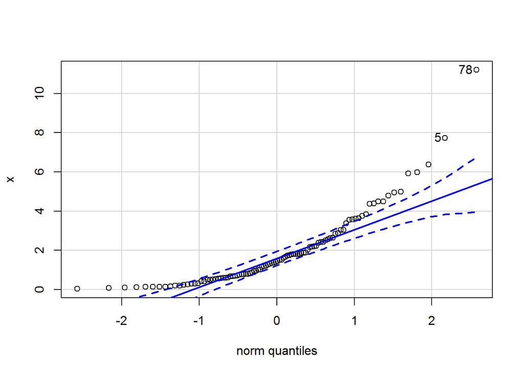

```
## [1] 78  5
```

```r
x<-rchisq(100, df=2)
qqPlot(x)
```

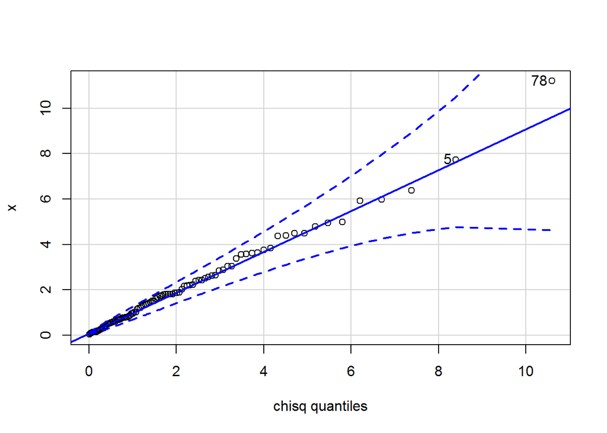

```
## [1] 78  5
```

```r
qqPlot(x, dist="chisq", df=2)
```

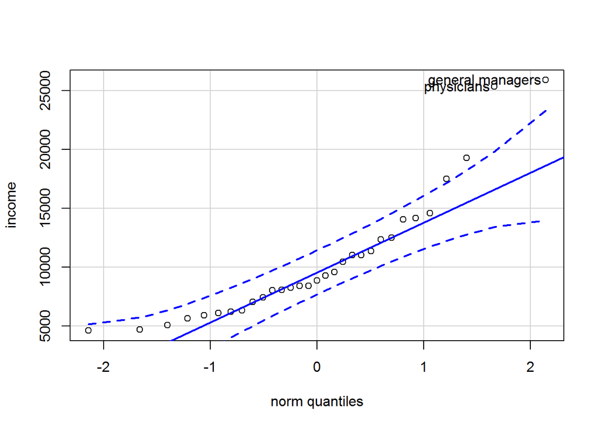

```
## general.managers       physicians
##                2               24
```

```r
qqPlot(~ income, data=Prestige, subset = type == "prof")
```